# Going beyond ReLTER

13/04/2022

## What can be done with ReLTER outputs

```r
pkg_list <- c("sf", "terra", "ReLTER", "tmap")
lapply(pkg_list, require, character.only = TRUE)
```

```
## [[1]]
## [1] TRUE
##
## [[2]]
## [1] TRUE
##
## [[3]]
## [1] TRUE
##
## [[4]]
## [1] TRUE
```

#### Each function returns an `R` object

- Site metadata and info returned as a `tibble`
  - save as an `R` dataset (keeps R stucture), or
  - save to csv file
- Boundaries are returned as an `sf` spatial vector layer.
  - save to a shapefile, or geopackage
- EO data are returned as a `SpatRaster` object (from the `terra` package)
  - save as geotiff

#### Example from the Doñana site in Spain

```r
donana = get_ilter_generalinfo(country_name = "Spain",
                              site_name = "Doñana")
donana_id = donana$uri
donana_polygon <- get_site_info(donana_id, category = "Boundaries")
donana_meta <-  get_site_info(donana_id,
                          c("Affiliations", "Contacts", "Parameters"))
# Get the Corine landcover from ODS
donana_clc <- get_site_ODS(donana_id, "clc2018")
```

Save data and spatial layers for use later, or in other GIS software

```r
# For this demo, save to temporary directory
output_dir = tempdir()
saveRDS(donana_meta, file.path(output_dir, "Donana_metadat.Rds"))
# Remove extra columns from polygon
donana_polygon <- donana_polygon[,c("title", "boundaries", "geoCoord", "geoElev.avg")]
st_write(donana_polygon,
         file.path(output_dir, "donana_polygon.gpkg"), append=FALSE)
```

```
## Writing layer `donana_polygon' to data source
##   `/tmp/Rtmppr3mhu/donana_polygon.gpkg' using driver `GPKG'
## Writing 1 features with 3 fields and geometry type Polygon.
```

```r
writeRaster(donana_clc,
            file.path(output_dir, "Donana_Corine2018.tif"),
            overwrite=TRUE)
```

## Rocker ReLTER

A Docker image for ReLTER package.

#### Capabilities

Run RStudio with preinstalled ReLTER package through Docker.

#### Quick setup

1. Follow the instructions to [install Docker on your computer](https://docs.docker.com/get-docker/).
2. Open a terminal (“command prompt” in Windows) and write the following command to download the rocker_relter image

```bash
docker pull ptagliolato/rocker_relter
```

1. Run the image:

```bash
docker run -e PASSWORD=yourpassword -p 8080:8787 \
  ptagliolato/rocker_relter
```

```
* This will run RStudio on port 8080, you can change the port as you like.
* You can change "yourpassword" with the password you prefer.
* If you close the terminal, the image will stop. To avoid this, add "-d" before "-e"
to run "detached" from the terminal.
* See further options in the last section.
```

#### Open your browser at localhost:8080 and login with

```
  user: rstudio
  password: yourpassword
```

#### Run experimental features of ReLTER package

ReLTER package is evolving. You can run some of the features recently added to the package (namely those presented in eLTER Plus deliverable D.4.1 to retrieve and manage biodiversity data from GBIF, OBIS and iNaturalist) by using the alternative image "dev__withImprovements":

```bash
docker pull ptagliolato/rocker_relter:dev__withImprovements

docker run -e PASSWORD=yourpassword -p 8080:8787 \
  ptagliolato/rocker_relter:dev__withImprovements
```

#### Preserve your work (use a docker volume)

When you stop a docker container, the files created within it are lost. In order to preserve your work across different runs, link a local volume (in this example, the current working directory, $(pwd)) to the container:

```bash
docker run -d -v $(pwd):/home/rstudio -e PASSWORD=yourpassword \
  -p 8080:8787 ptagliolato/rocker_relter
```

## Merging other data

The site boundary, obtained from https://DEIMS.org can be used to crop and mask EO data from other sources. In this section we show use of global EO data acquired from a new `R` package `geodata`. Elevation from the Shuttle Radar Terrain Mission (SRTM) and species distribution from Global Biodiversity Information Facility (GBIF) will be downloaded, cropped to a site boundary and compared. The Gran Paradiso National Park will be used, and this example will examine *Capra ibex* sitings

#### Get Gran Paradiso boundary

```r
paradiso <- get_ilter_generalinfo(country_name = "Italy",
                                site_name = "Gran Paradiso")
paradiso_id <- paradiso[2,]$uri
paradiso_boundary <- get_site_info(paradiso_id, "Boundaries")
```

#### Install `geodata` package and download SRTM over Northern Italy

```r
# Get the geodata package
if (!require(geodata)) {
  install.packages("geodata", dependencies = TRUE)
  library(geodata)
}
italy_srtm <- elevation_3s(lon = 7.5, lat = 47.5, path = tempdir())
paradiso_srtm <- mask(crop(italy_srtm, vect(paradiso_boundary)),
                      vect(paradiso_boundary))
names(paradiso_srtm) <- "Elev"
```

#### Query GBIF for *Capra ibex*

```r
# Download data
ibex <- sp_occurrence("Capra", species = "ibex",
                            ext = ext(paradiso_boundary))
```

```
## 222 records found
```

```
## 0-222
## 222 records downloaded
```

```r
ibex <- ibex[,c("lon", "lat")]
ibex <- ibex[complete.cases(ibex),]
# Convert to `sf`
ibex_points <- st_as_sf(ibex, coords = c("lon", "lat"), crs = "EPSG:4326")
```

#### Now extract elevation from SRTM at each Ibex siting location

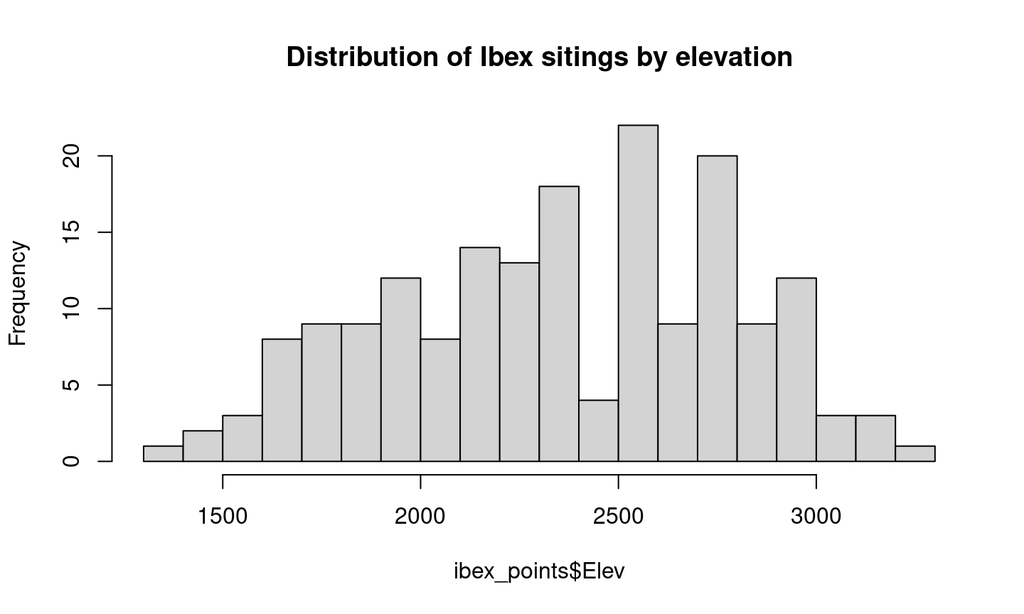

```r
ibex_elev <- extract(x = paradiso_srtm, y=vect(ibex_points))
ibex_points <- cbind(ibex_points, ibex_elev)
hist(ibex_points$Elev, breaks=20,
     main = "Distribution of Ibex sitings by elevation")
```

Prepare hill-shade raster

```r
# Create hillshade raster
slope <-  terrain(paradiso_srtm, "slope", unit = "radians")
aspect <-  terrain(paradiso_srtm, "aspect", unit="radians")
hill_shade = shade(slope, aspect, angle=35, direction = 310)
```

Prepare a plot, including hillshade effect

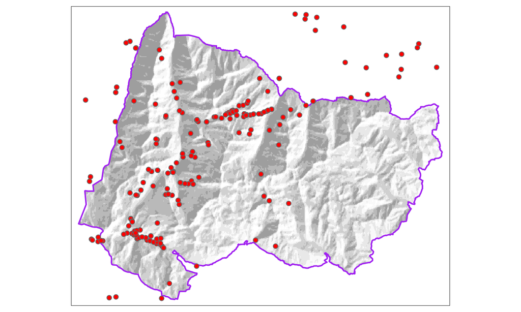

```r
tm_basemap("OpenStreetMap.Mapnik") +
  tm_shape(hill_shade) +
  tm_raster(alpha = 0.4, palette = "Greys",
            n=8, legend.show = FALSE) +
  tm_shape(paradiso_boundary) +
  tm_borders(col = "purple", lwd = 2) +
  tm_shape(ibex_points) +
  tm_symbols(size=0.2, col = "red")
```

## Future plans

- Acquire MODIS products
  - Time series
- Acquire species distribution from GBIF: https://www.gbif.org/dataset/search
- Acquire high resolution landcover data from ESA Worldcover: https://esa-worldcover.org/